# Praca domowa 2

Maria Harbaty

## Dane

Dane wykorzystane w Pracy domowej 2 są związane z kampaniami marketingu bezpośredniego portugalskiej instytucji bankowej. Kampanie marketingowe opierały się na rozmowach telefonicznych. Często wymagany był więcej niż jeden kontakt z tym samym klientem, aby uzyskać dostęp do tego, czy produkt (lokata bankowa) zostanie (lub nie) subskrybowany. Opis wszystkich kolumn znajduje się również w pliku `README.md`.

#### Dane klienta banku

| Zmienna | Opis |
| --- | --- |
| **age** | wiek |
| **job** : admin., unknown, unemployed, management, housemaid, entrepreneur, student, blue-collar, self-employed, retired, technician, services | administrator, nieznany, bezrobotny, kierownictwo, pokojówka, przedsiębiorca, student, pracownik fizyczny, samozatrudniony, emeryt, technik, usługi |
| **marital** : married, divorced, single; note: divorced means divorced or widowed) | żonaty/zamężna, rozwiedzion_, kawaler/panna; uwaga: rozwiedzion_ oznacza rozwiedzion_ lub owdowiał_ |
| **education** : unknown, secondary, primary, tertiary | nieznane, średnie, podstawowe, wyższe |
| **default** : yes, no | czy kredyt jest niespłacany : tak, nie |
| **balance** : average yearly balance, in euros | średnie roczne saldo w euro |
| **housing** : has housing loan? yes, no | czy posiada kredyt mieszkaniowy? tak, nie |
| **loan** : has personal loan? yes, no | ma pożyczkę osobistą? tak, nie |

#### Dane związane z ostatnim kontaktem w bieżącej kampanii

| Zmienna | Opis |
| --- | --- |
| **contact** : unknown, telephone, cellular | nieznany, telefon, komórkowy |
| **day** : last contact day of the month | dzień miesiąca ostatniego kontaktu |
| **month** : last contact month of year, jan, feb, mar, …, nov, dec | miesiąc ostatniego kontaktu w roku, styczeń, luty, marzec, …, listopad, grudzień |
| **duration** : last contact duration, in seconds | czas trwania ostatniego kontaktu w sekundach |

## Zadanie 1

Weźmy pod uwagę zawody (`job`) klientów banku. Który zawód zacząco wyróżnia się w posiadaniu kredytu mieszkaniowego lub pożyczki osobistej?

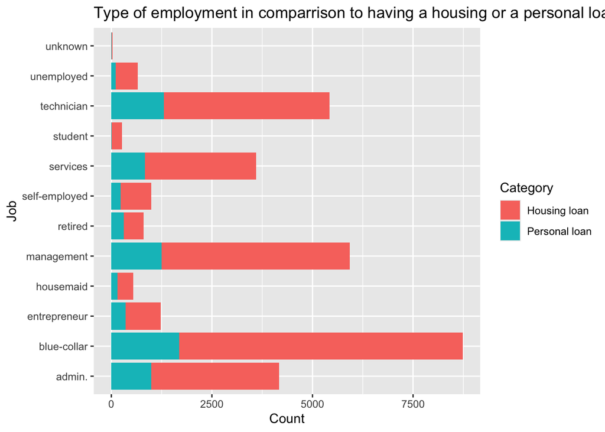

```r
# Zrobię wykres kolumnowy ukazujący ilość osób w danym zawodze posiadających kredyt mieszkaniowy lub pożyczkę osobistą.

df %>%
  mutate(
    housing = ifelse(housing == "yes", 1, 0),
    loan = ifelse(loan == "yes", 1, 0)
  ) %>%
  group_by(job) %>%
  summarise(
    n_house = sum(housing,na.rm = TRUE),
    n_loan = sum(loan,na.rm = TRUE)
  ) %>%
  pivot_longer(cols = c(n_house, n_loan), names_to = "Category", values_to = "n") %>%
  ggplot(aes(x = job, y = n, fill = Category)) +
  scale_fill_discrete(labels = c("n_house" = "Housing loan", "n_loan" = "Personal loan")) +
  geom_col() +
  coord_flip() +
  labs(title = "Type of employment in comparrison to having a housing or a personal loan",
       x = "Job",
       y = "Count")
```

**Komentarz: Można tutaj zauważyć, że pracownicy fizyczni posiadają najwięcej kredytów mieszkaniowych oraz osobistych.**

## Zadanie 2

Wybierając klientów, którzy mają nieznany sposób kontaktu (`contact`). Jak rozkłada się ich wiek w podziale na status związku?

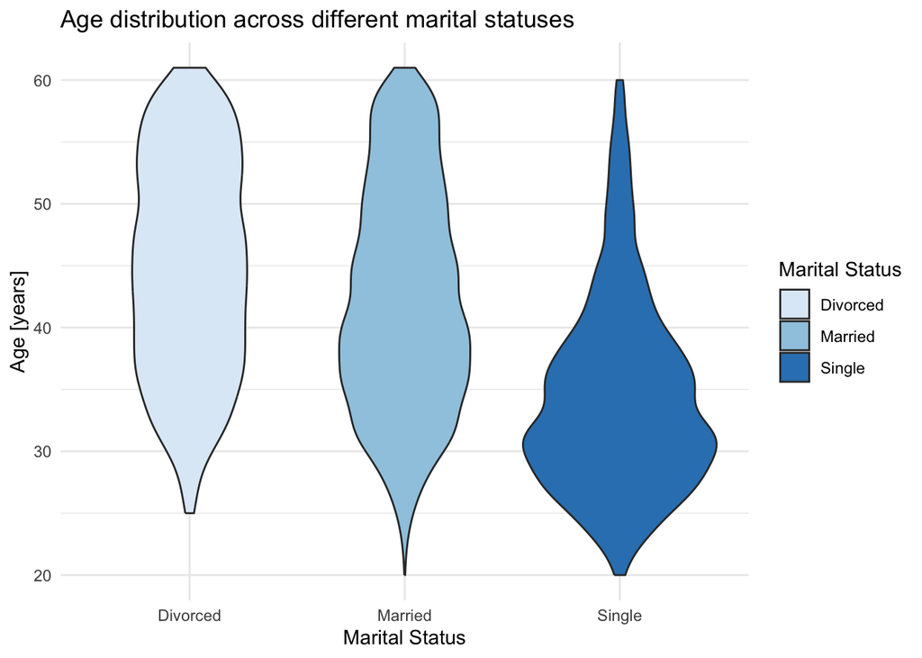

```r
df %>%
  filter(contact == "unknown")%>%
  ggplot(aes(x = marital, y = age,fill = marital)) +
  geom_violin() +
  theme_minimal() +
  scale_x_discrete(labels = c("divorced" = "Divorced", "married" = "Married", "single" = "Single", "marital" = "Marital Status")) +
  scale_fill_manual(values = RColorBrewer::brewer.pal(n = 3, name = "Blues"), labels = c("divorced" = "Divorced", "married" = "Married", "single" = "Single", "marital" = "Marital status")) +
  labs(title = "Age distribution across different marital statuses",
       x = "Marital Status",
       y = "Age [years]",
       fill = "Marital Status" )
```

## Zadanie 3

Jaka jest różnica pomiędzy średnim rocznym saldem w euro w zależności od wykształcenia i tego czy kredyt jest niespłacany?

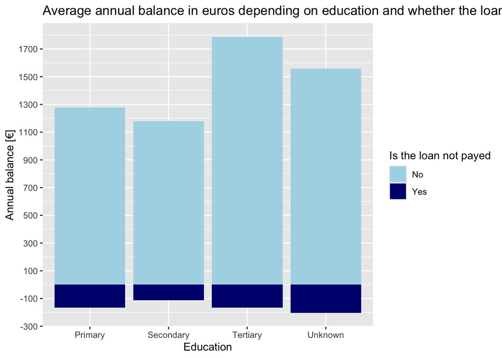

```r
df %>%
  group_by(education,default) %>%
  summarise(n = mean(balance)) %>%
  ggplot(aes(x = education, y = n, fill = default)) +
  geom_col() +
  labs(title = "Average annual balance in euros depending on education and whether the loan is unpaid",
       x = "Education",
       y = "Annual balance [€]",
       fill = "Is the loan not payed" ) +
  scale_x_discrete(labels = c("primary" = "Primary", "secondary" = "Secondary","tertiary" = "Tertiary", "unknown" = "Unknown"))+
  scale_fill_manual(values = c("yes" = "navy", "no" = "lightblue"),labels = c("yes" = "Yes", "no" = "No")) +
  scale_y_continuous(breaks = seq(-300, 1800, by = 200))
```

**Komentarz: Widzimy, że przy wyższym wykształceniu dodatnie saldo na koncie, gdy kredyt jest spłacany jest większe niż w innych przypadkach.**

## Zadanie 4

Czy dzień i miesiąc kontaktu z klientem ma wpływ na średni czas trwania rozmowy w stosunku do średniego czasu trwania rozmowy?

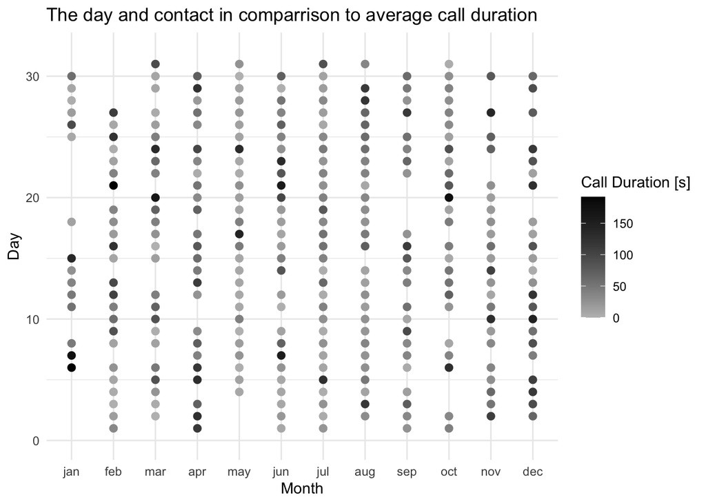

```r
# najpierw sobię obliczę średnia a następnie ją sobie odejmę
x <- df %>%
  summarise(n = mean(duration))
x<- floor(x[[1]])

df %>%
  group_by(day,month) %>%
  summarise(n = floor(mean(duration))) %>%
  mutate(n = abs(x-n)) %>%
  mutate(month = factor(month,levels = c("jan", "feb", "mar", "apr","may","jun","jul","aug","sep","oct","nov","dec"))) %>%
  filter(n < 200) %>%
  ggplot(aes (x = month, y = day, color = n)) +
  geom_point(size = 2.2) +
  scale_color_gradient(low = "grey", high = "black") +
  theme_minimal() +
  labs(title = "The day and contact in comparrison to average call duration",
       x = "Month",
       y = "Day",
       color = "Call Duration [s]") +
  ylim(0,32)
```

## Zadanie 5

Czy jest zależnośc pomiędzy wiekiem klientów a ich średnim rocznym saldzie w euro w podziale na stopień wykształcenia?

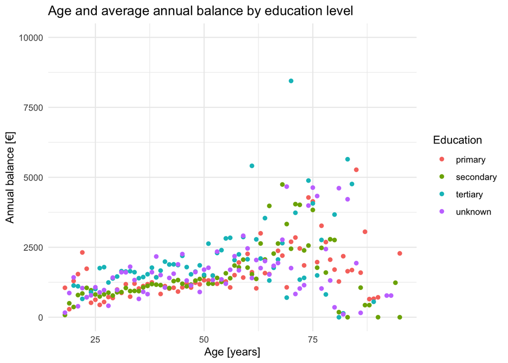

```r
df %>%
  group_by(age,education) %>%
  summarise(n = floor(mean(balance))) %>%
  filter(n<10000) %>%
  ggplot(aes(x = age, y = n, colour = education)) +
  geom_point() +
  theme_minimal()+
  labs(title = "Age and average annual balance by education level",
       x = "Age [years]",
       y = "Annual balance [€]",
       colour = "Education") +
  ylim(0,10000)
```

**Komentarz: Widać, że wraz ze wzrostem wieku następuje większa dywersyfikacja rozkładu salda na koncie. U części się zwiększyła, jednka u części spadła.**

## Zadanie 6

Rozważmy osoby, które są bezrobotne albo ich zawód jest nieznany. Czy procent osób, które są bezrobotne i nie spłacają kredytu jest większy od procenta osób o nieznanym zawodzie i nie spłacanym kredycie? Jaki typ kredytu jest (przez te osoby) najczęściej niespłacany?

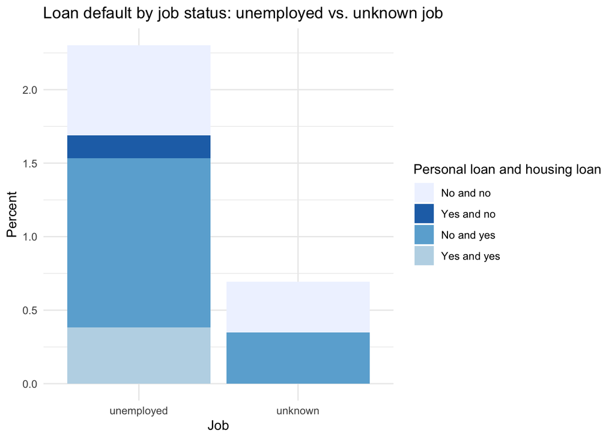

```r
df %>%
  filter(job == "unknown"| job == "unemployed") %>%
  group_by(job, housing,loan,default) %>%
  summarise(n = n()) %>%
  group_by(job) %>%
  mutate(percent = n / sum(n) * 100) %>%
  filter(default == "yes") %>%
  ggplot(aes(x = job, y = percent, fill = interaction(loan,housing))) +
  geom_col() +
  labs(title = "Loan default by job status: unemployed vs. unknown job",
       x = "Job",
       y = "Percent",
       fill = "Personal loan and housing loan") +
  scale_fill_manual( values = c("no.no" = "#EFF3FF", "yes.yes" = "#BDD7E7", "no.yes" = "#6BAED6","yes.no" = "#2171B5"),labels = c("no.no" = "No and no", "yes.yes" = "Yes and yes", "no.yes" = "No and yes", "yes.no" = "Yes and no")) +
  theme_minimal()
```

```r
RColorBrewer::brewer.pal(n = 4, name = "Blues")
```

```
## [1] "#EFF3FF" "#BDD7E7" "#6BAED6" "#2171B5"
```